# Algorithmic Fairness

A crucial aspect of deploying machine learning (ML) models in clinical laboratories is ensuring that they achieve their desired goals without introducing or exacerbating inequity in healthcare delivery. We will examine these vulnerabilities through the lens of fairness concepts and their metrics during the model validation process. Azimi and Zaydman<sup>1</sup> have provided a more comprehensive overview of the key considerations for laboratory medicine.

## Fairness Concepts

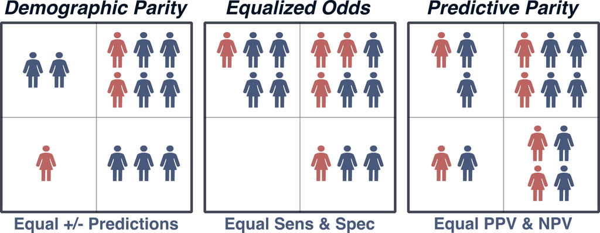

Concepts of algorithmic fairness, adapted from [Azimi and Zaydman](https://pubmed.ncbi.nlm.nih.gov/36610413/).

Predictive performance can be contextualized within three concepts of group fairness;

- *Demographic parity*, where model flag rates are identical across subgroups,
- *Equalized odds*, where sensitivity and specificity are identical across subgroups,
- *Predictive parity*, where PPV and NPV are identical across subgroups.

## Assessing Fairness in Contamination Predictions

```r
suppressPackageStartupMessages(library(tidyverse))
suppressPackageStartupMessages(library(tidymodels))
options(timeout = 300)

## Load models
model_realtime <- read_rds("https://api.figshare.com/v2/file/download/45631488") |> pluck("model") |> bundle::unbundle()
model_retrospective <- read_rds("https://api.figshare.com/v2/file/download/45631491") |> pluck("model") |> bundle::unbundle()
model_realtime$fit$fit$ordered <- FALSE
model_retrospective$fit$fit$ordered <- FALSE
predictors <- model_retrospective |> extract_recipe() |> pluck("term_info") |> dplyr::filter(role == "predictor") |> pluck("variable")

## Load validation data
validation <- arrow::read_feather("https://api.figshare.com/v2/file/download/45407398") |> select(any_of(predictors))

## Add ground-truth labels via retrospective model
validation_with_ground_truth <- augment(model_retrospective, validation |> drop_na(any_of(predictors))) |> mutate(truth = factor(.pred_class, labels = c("Negative", "Positive"))) |> select(-matches("pred"))

## Randomly assign two-thirds of the positive classes to females
validation_with_sex_labels <-
  validation_with_ground_truth |>
    mutate(sex = ifelse(truth == "Positive", sample(c("Male", "Female"), size = n(), replace = TRUE, prob = c(1, 2)), NA_character_))

## Assign equal proportions of the negative classes to each sex
validation_with_sex_labels <-
  validation_with_sex_labels |>
    mutate(sex = ifelse(truth == "Negative", sample(c("Male", "Female"), size = n(), replace = TRUE), sex))
```

Let’s explore how we will calculate these metrics using our normal saline predictor in *R*.

First, we’ll add a set of simulated labels to our validation set.

We’ll make contamination twice as common in females as in males.

Contaminated Results by Sex

|  | Female | Male |
| --- | --- | --- |
| Negative | 136807 | 137511 |
| Positive | 1196 | 590 |

### Calculating Group-Wise Performance Metrics

Next, we’ll calculate a set of performance metrics, including sensitivity, specificity, positive predictive value (PPV), negative predictive value (NPV), and flag rate, for each sex (*left*).

Then, we’ll compare these metrics across the demographic groups using the fairness concepts described above (*right*).

```r
## Apply real-time predictions
validation_realtime_preds <- augment(model_realtime, validation_with_sex_labels) |> mutate(pred = factor(.pred_class, labels = c("Negative", "Positive")))

## Calculate group-wise performance metrics
metrics_to_calculate <- metric_set(sens, spec, ppv, npv, detection_prevalence)
groupwise_metrics <-
  validation_realtime_preds |>
    group_by(sex) |>
    metrics_to_calculate(truth = truth, estimate = pred, event_level = "second") |>
    transmute(Metric = str_to_upper(.metric), Value = .estimate, Sex = sex) |>
    mutate(Metric = ifelse(Metric == "DETECTION_PREVALENCE", "FLAG RATE", Metric))

## Output metrics comparison
metric_table <- groupwise_metrics |> pivot_wider(id_cols = Sex, names_from = Metric, values_from = Value) |> knitr::kable(digits = 3)

## Add predictive parity to yardstick's prebuilt functions
diff_range <- function(x) {diff(range(x$.estimate))}
predictive_parity <- new_groupwise_metric(ppv, name = "predictive_parity", aggregate = diff_range)

## Define fairness metrics to calculate
fairness_metrics <- metric_set(demographic_parity(by = sex), equalized_odds(by = sex), predictive_parity(by = sex))

## Calculate fairness metrics
validation_fairness <-
  validation_realtime_preds |>
    fairness_metrics(truth = truth, estimate = pred, event_level = "second") |>
    transmute(Metric = str_to_upper(.metric), `Metric Difference` = .estimate)

## Make fairness table
fairness_table <- validation_fairness |> knitr::kable(digits = 3)
```

| Sex | SENS | SPEC | PPV | NPV | FLAG RATE |
| --- | --- | --- | --- | --- | --- |
| Female | 0.789 | 0.996 | 0.628 | 0.998 | 0.011 |
| Male | 0.802 | 0.996 | 0.435 | 0.999 | 0.008 |

| Metric | Metric Difference |
| --- | --- |
| DEMOGRAPHIC_PARITY | 0.003 |
| EQUALIZED_ODDS | 0.012 |
| PREDICTIVE_PARITY | 0.193 |

### Conclusions

Differences in incidence of contamination across the demographic groups leads to:

- *Discrepant positive predictive values and poor predictive parity.*

Class imbalance, with positive cases being quite rare, leads to:

- *Large relative, but small absolute, differences in flag rate.*

Given the random nature of the assigned labels:

- *Sensitivity and specificity are nearly identical across groups.*

*Key Takeaway:*  
Performance assessment should incorporate concepts of algorithmic fairness to protect against the introduction or exacerbation of inequity.

## References

1.

Azimi V, Zaydman MA. [Optimizing Equity: Working towards Fair Machine Learning Algorithms in Laboratory Medicine](https://doi.org/10.1093/jalm/jfac085). The Journal of Applied Laboratory Medicine 2023;8(1):113–28.